# Emotion Detection - from Text Input

# 13.3 Pull Docker Image from Docker Hub and use it to classify emotions

$> docker login $> docker image pull rchai/text-emotion-detection:trained_on_dair-ai_emotion $> docker run --rm -p 3000:3000 rchai/text-emotion-detection:trained_on_dair-ai_emotion curl -X POST -H "accept: text/plain" -H "content-type: text/plain" --data "who are you?" http://127.0.0.1:3000/classifyemotion curl -X POST -H "accept: text/plain" -H "content-type: text/plain" --data "the cake was mouthwatering delicious! Yummy!" http://127.0.0.1:3000/classifyemotion

##### use Curl to test on the running container

$> curl -X POST -H "accept: text/plain" -H "content-type: text/plain" --data "who are you?" http://127.0.0.1:3000/classifyemotion $> curl -X POST -H "accept: text/plain" -H "content-type: text/plain" --data "the cake was mouthwatering delicious! Yummy!" http://127.0.0.1:3000/classifyemotion

##### ==================================================================================

$> docker login

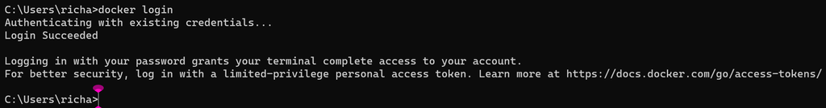

$> docker image pull rchai/text-emotion-detection:trained_on_dair-ai_emotion

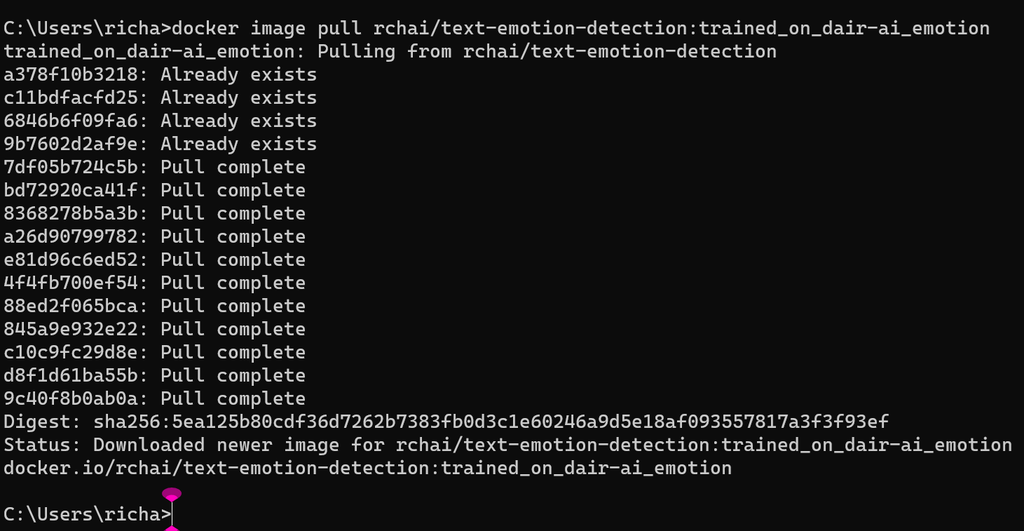

$> docker run --rm -p 3000:3000 rchai/text-emotion-detection:trained_on_dair-ai_emotion

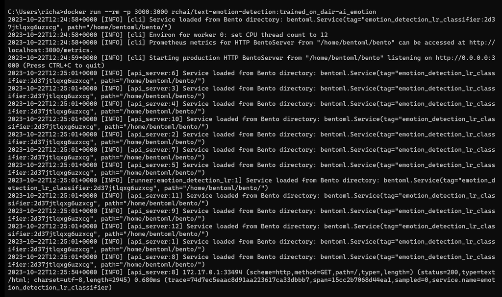

[figure not shown]

curl -X POST -H "accept: text/plain" -H "content-type: text/plain" --data "the cake was mouthwatering delicious! Yummy!" http://127.0.0.1:3000/classifyemotion

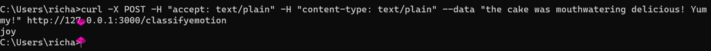

curl -X POST -H "accept: text/plain" -H "content-type: text/plain" --data "This question is so difficult, I got it wrong 3 times already." http://127.0.0.1:3000/classifyemotion

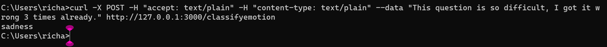

curl -X POST -H "accept: text/plain" -H "content-type: text/plain" --data "This is crazy, what a stupid question!" http://127.0.0.1:3000/classifyemotion

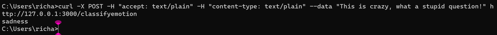

hmmm ... I would think 'anger' or 'frustration' (not available in this training dataset) would be more appropriate than 'sadness'. The distilbert model got this right. This Logistic Regression model while usable for a proof-of-concept can do with improvements.curl -X POST -H "accept: text/plain" -H "content-type: text/plain" --data "I've been waiting so long for this day, finally, it's here!" http://127.0.0.1:3000/classifyemotion

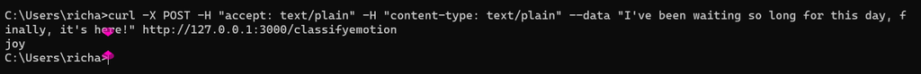

The distilbert model got this wrong while the Logistic Regression Model got this correct. But models need improvements.